# Визуализация данных в R

# DBSCAN

Общий принцип:

1. Произвольно выберем точку p
2. Присвоим к её кластеру все точки, в радиусе EPS. Для каждой из них сделаем тоже самое и так до тех пор, пока на новом шаге в радиус не попадёт ни одна точка. Здесь тажке важен параметр манимального количества точек, попадающего в радиус Min Pts (чем он больше, тем гуще будут наши кластеры)
3. После того как один кластер сложился, случайным образом назначается вторая точка. Из неё строится второй клстер
4. Шаг 3 идёт до тех пор, пока новые точки-основы-кластеров не смогут образовать новый кластер (вокруг них ничего нет или число точек меньше чем Min Pts). В этом случае мы помечаем оставшиеся точки как шум

Визуально, это выглядит так:

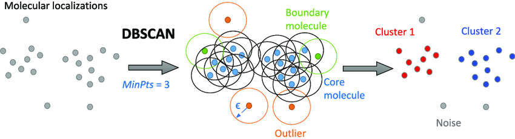

Ещё раз о терминах:

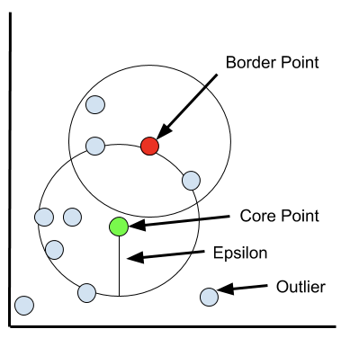

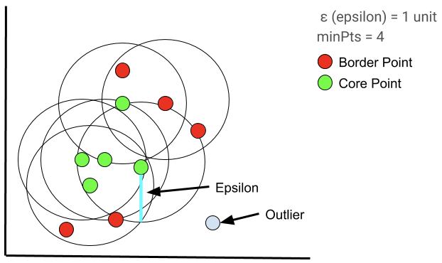

Посмотрим как работает DBSCAN на [этом сайте](https://www.naftaliharris.com/blog/visualizing-dbscan-clustering/).

Как это применяется:

```r
# Health systems
hs.db <- fpc::dbscan(hs_scaled,
                  eps = 1.8, # Радиус
                  MinPts = 5) # Количество точек в пределах радиуса. Минимальное значение 3
hs.db
```

```
## dbscan Pts=124 MinPts=5 eps=1.8
##         0   1  2
## border 12  13  3
## seed    0  88  8
## total  12 101 11
```

```r
# Iris
iris.db <- fpc::dbscan(iris_scaled,
                  eps = 0.6, # Радиус
                  MinPts = 7)
iris.db
```

```
## dbscan Pts=150 MinPts=7 eps=0.6
##         0  1  2
## border 31  5 20
## seed    0 41 53
## total  31 46 73
```

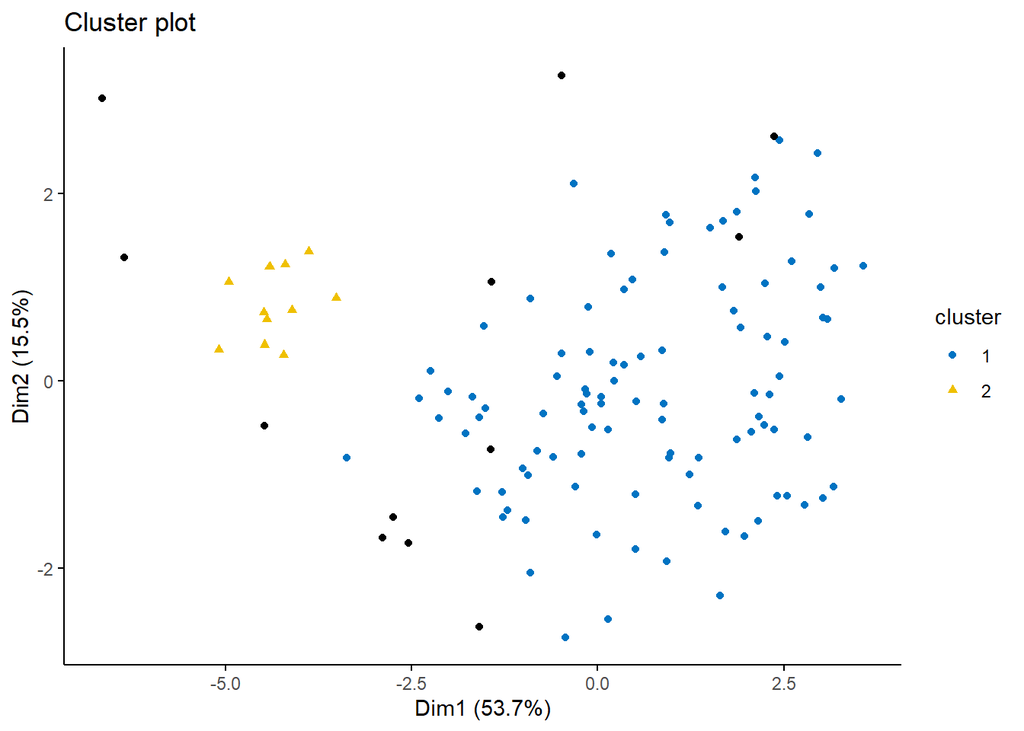

```r
# HS
fviz_cluster(hs.db, data = hs_scaled, stand = FALSE,
             ellipse = FALSE, show.clust.cent = FALSE,
             geom = "point", palette = "jco", ggtheme = theme_classic())
```

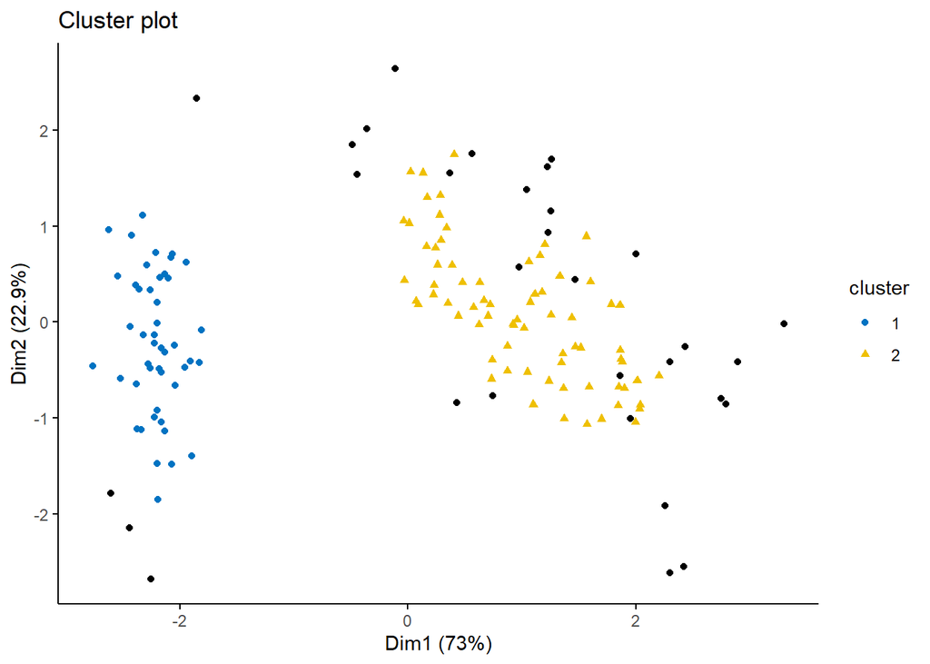

```r
# Iris
fviz_cluster(iris.db, data = iris_scaled, stand = FALSE,
             ellipse = FALSE, show.clust.cent = FALSE,
             geom = "point", palette = "jco", ggtheme = theme_classic())
```

Как выбрать eps? Нужно посчитать среднюю дистанцию между точкой и ближайшими соседями (опять ищем локти)

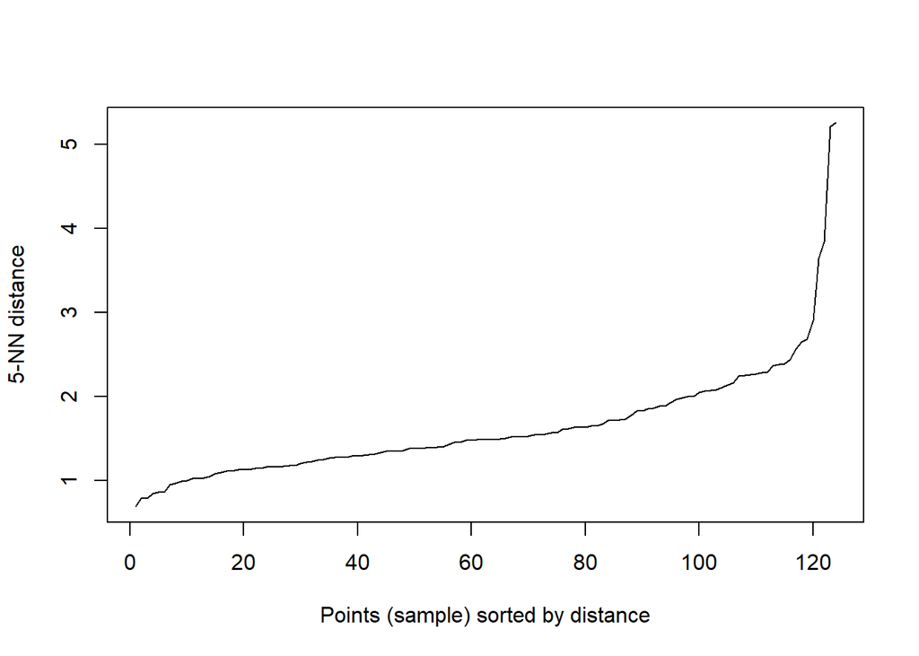

```r
dbscan::kNNdistplot(hs_scaled,
                    k = 5) # Число соседей - чем меньше, тем более сгруппированные кластеры мы хотим получить
```

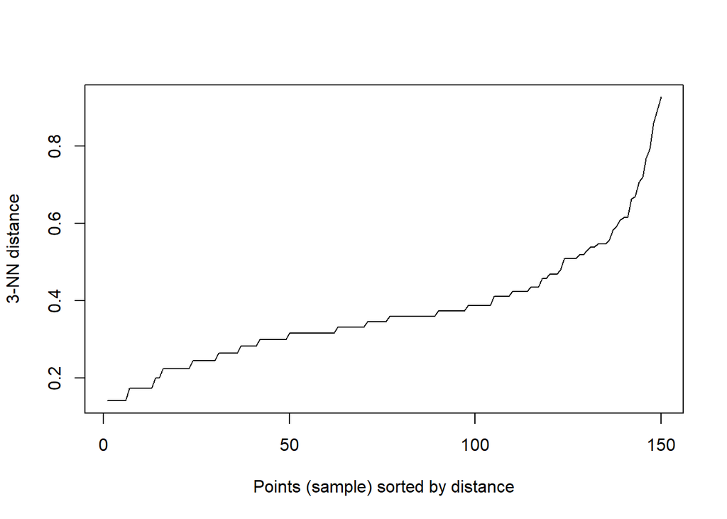

```r
dbscan::kNNdistplot(iris,
                    k = 3)
```

Как определить оптимальные minPts? Единого способа нет, стоит смотреть экспериментально, с учётом следующего:

- Чем больше набор данных, тем больше должно быть значение MinPts
- Если набор данных разряженный, выберайте большее значение MinPts
- Для двумерных данных используйте значение MinPts = 4 (Ester et al., 1996)
- Если ваши данные имеют более двух измерений, выберите MinPts = 2*dim(x)[2], где dim - размерность ваших изначальных данных (Sander et al., 1998).

…Экспериментируйте!

**Плюсы DBSCAN**

- Не требует от нас предварительного определения количества кластеров, таких как KMeans.
- Обрабатывает выбросы как чемпион
- Может разделять данные с высокой плотностью на небольшие кластеры
- Может кластеризовать нелинейные отношения (находит произвольные формы)

**Минусы DBSCAN**

- Проблемы с идентификацией кластеров в данных различной плотности.
- Могут пострадать данные с высокой размерностью
- Очень чувствителен к параметрам epsilon и минимальным точкам

# Оценки кластеризации

Что даёт нам утверждать, что алгоритм действительно хорошо сработал и нашёл кластеры?

## Для иерархических кластеризаций

Один из способов оценки иерархической кластеризации - измерить, насколько хорошо дерево кластеров, сгенерированное функцией hclust(), отражает ваши данные. В базовом варианте анализируют корреляцию cophentic distance данных кластеризации с оригинальной матрицей дистанций.

Если кластеризация прошла хорошо (конвенционально больше 0.75), то, считается, кластеризация прошла хорошо.

```r
# Cophentic distance
hs_dist.coph <- cophenetic(hs_dist.hc)
# Корреляция
cor(hs_dist, hs_dist.coph)
```

```
## [1] 0.5564441
```

## Методы оценки наличия кластеров в данных

### Статистический - тест Хопкинса (Hopkins statistic)

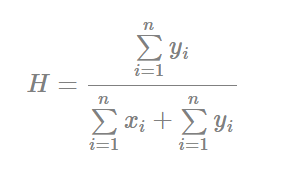

Hopkins statistic - Считаем расстояние до ближайшего соседа для каждой точки, потом сравниваем суммарные расстояния со сгенерированным стандартизированным датасетом той же размерности.

- Нулевая гипотезза - Данные распределены равномерно, т.е. кластеров нет
- Альтернативная гипотза - Данные распределены неравномерно, т.е. есть вероятность получить хорошую кластеризацию

Существует некоторая [путанница](https://stats.stackexchange.com/questions/332651/validating-cluster-tendency-using-hopkins-statistic) с интерпретацией статистики Хопкинса. Проблема в том, что в пакете factoextra она считается как H, а в другом популярном пакете clustertrends как 1-H.

Мы воспользуемся первым решением. Согласно ему, конвенционально, если H>0.7, то мы можем принимать альтернативную гипотезу. Чем ближе H к 1, тем более выраженные в данных кластеры.

```r
get_clust_tendency(hs_scaled,
                   n = nrow(hs_scaled)-1)[1]
```

```
## $hopkins_stat
## [1] 0.822338
```

Сравним со случайным датасетом той же размерности:

```r
# Сгенерируем его
random_df <- apply(hs_scaled, 2,
                   function(x){runif(length(x), min(x), (max(x)))})

# Hopkins
hopkins(random_df,
        n = nrow(random_df)-1)[1]
```

```
## $H
## [1] 0.5032629
```

### Визуальная оценка

Рассчитаем матрицу различий (dissimilarity matrix) в данных, а затем упорядочим её. При наличии кластеров в данных мы должны визуально увидеть определённый порядок. Пример:

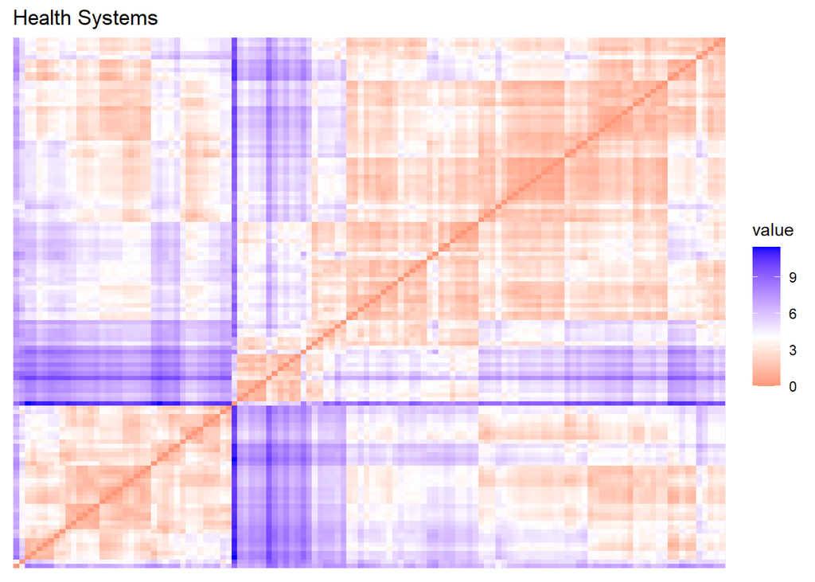

```r
fviz_dist(hs_dist, show_labels = FALSE)+
  labs(title = "Health Systems")
```

Сравним со случайными данными:

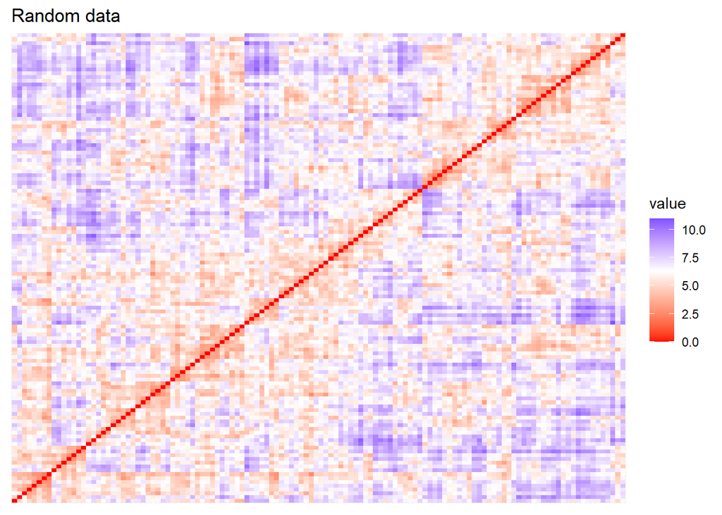

```r
fviz_dist(dist(random_df), show_labels = FALSE)+
  labs(title = "Random data")
```

## Методы оценки качества кластеризации

### Silhouette plot

Визуализация графика по мере силуэта. График силуэта отображает меру того, насколько близка каждая точка в одном кластере к точкам в соседних кластерах. Чем ближе значение к 1, тем лучше наблюдение относится к своему кластеру и подобно наблюдениям в нём. Если значение ближе к -1, наблюдение не похоже на объекты в своём кластере (скорее всего оно должно относится к другому кластеру).

```
##   cluster size ave.sil.width
## 1       1   88          0.14
## 2       2   23          0.26
## 3       3   13          0.45
```

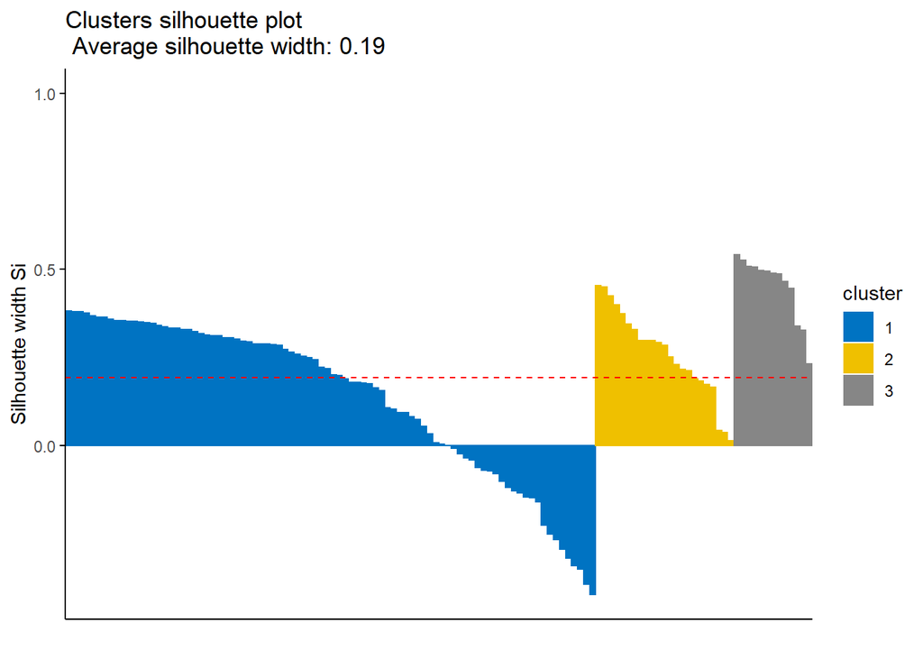

```r
sil <- silhouette(hs_kmean$cluster,
                  hs_dist)
fviz_silhouette(sil, palette = "jco",
                ggtheme = theme_classic())
```

### Dunn index (Индекс Данна)

Минимальное расстояние между кластерами делим на максимальное расстояние внутри кластеров. Чем больше значение, тем лучше качество кластеризации:

```r
hs_stats <- fpc::cluster.stats(hs_dist,
                               hs_kmean$cluster)
# Dunn index
hs_stats$dunn
```

```
## [1] 0.06537346
```

Обратите внимание на остальные метрики ():

```r
hs_stats
```

```
## $n
## [1] 124
##
## $cluster.number
## [1] 3
##
## $cluster.size
## [1] 88 23 13
##
## $min.cluster.size
## [1] 13
##
## $noisen
## [1] 0
##
## $diameter
## [1] 8.621467 6.740160 5.979343
##
## $average.distance
## [1] 3.372561 2.782410 2.504123
##
## $median.distance
## [1] 3.281564 2.571512 2.177097
##
## $separation
## [1] 0.5636151 0.5636151 1.8556227
##
## $average.toother
## [1] 5.012602 4.129865 6.241628
##
## $separation.matrix
##           [,1]      [,2]     [,3]
## [1,] 0.0000000 0.5636151 2.967514
## [2,] 0.5636151 0.0000000 1.855623
## [3,] 2.9675136 1.8556227 0.000000
##
## $ave.between.matrix
##          [,1]     [,2]     [,3]
## [1,] 0.000000 4.067917 6.683967
## [2,] 4.067917 0.000000 4.549203
```

[output cut: 53 more lines]

```
##
## $cwidegap
## [1] 3.541487 3.401679 4.469430
##
## $widestgap
## [1] 4.46943
##
## $sindex
## [1] 0.8136982
##
## $corrected.rand
## NULL
##
## $vi
## NULL
```

# Полезные ссылки

- Soetewey A. (2017) [The complete guide to clustering analysis: k-means and hierarchical clustering by hand and in R](https://statsandr.com/blog/clustering-analysis-k-means-and-hierarchical-clustering-by-hand-and-in-r/)
- Pang-Ning T. et al (2017) [Clustering Analysis](https://mhahsler.github.io/Introduction_to_Data_Mining_R_Examples/book/clustering-analysis.html) In. An R Companion for Introduction to Data Mining.
- Alboukadel K. (2018) [Assessing Clustering Tendency](https://www.datanovia.com/en/lessons/assessing-clustering-tendency/)